# BankChurnPrediction

## Bank Churn Prediction Case Study

### Problem Definition

- Mostly banks that provide service have to worry about the problem of 'Churn' (customers leaving and joining another service provider). It is important to understand which aspects of the service influence a customer's decision in this regard. Management can concentrate efforts on the improvement of service, keeping in mind these priorities.

### Objective

- Given a Bank customer, build a neural network-based classifier that can determine whether they will leave or not in the next 6 months.
- The dataset contains about 10,000 sample points with 14 distinct features such as CustomerId, CreditScore, Geography, Gender, Age, Tenure, Balance, etc.

### Brief Approach

#### Loading all required libraries to perform Assignment.

```python
# this will help in making the Python code more structured automatically (good coding practice)
%load_ext nb_black

import pandas as pd
import numpy as np
from sklearn.model_selection import train_test_split
import tensorflow as tf
from sklearn import preprocessing
from tensorflow.keras.models import Sequential
from tensorflow.keras.layers import Dense, Dropout
from sklearn.metrics import (
    accuracy_score,
    confusion_matrix,
    precision_score,
    recall_score,
    f1_score,
    precision_recall_curve,
    auc,
)
import matplotlib.pyplot as plt
from tensorflow.keras import optimizers
from sklearn.decomposition import PCA
import seaborn as sns
import keras
import tensorflow as tf
from keras import backend as K
from keras.models import Sequential
from keras.layers import Dense, Dropout

# library to import to standardize the data
from sklearn.preprocessing import StandardScaler

# Importing optimizers
from tensorflow.keras.optimizers import Adam
from tensorflow.keras.optimizers import RMSprop

# Importing Batch Normalization
from keras.layers import BatchNormalization

# Importing classback API
from keras import callbacks

import os

# To supress warnings
import warnings

warnings.filterwarnings("ignore")
```

##### Load and overview the dataset

```python
df = pd.read_csv("Churn.csv")
```

```python
# Copying the dataset.
```

```python
data = df.copy()
```

```python
data.shape
```

```
(10000, 14)
```

- There are about 14 columns and 10000 rows exist in the given dataset

```python
data.head()
```

|  | RowNumber | CustomerId | Surname | CreditScore | Geography | Gender | Age | Tenure | Balance | NumOfProducts | HasCrCard | IsActiveMember | EstimatedSalary | Exited |
| --- | --- | --- | --- | --- | --- | --- | --- | --- | --- | --- | --- | --- | --- | --- |
| 0 | 1 | 15634602 | Hargrave | 619 | France | Female | 42 | 2 | 0.00 | 1 | 1 | 1 | 101348.88 | 1 |
| 1 | 2 | 15647311 | Hill | 608 | Spain | Female | 41 | 1 | 83807.86 | 1 | 0 | 1 | 112542.58 | 0 |
| 2 | 3 | 15619304 | Onio | 502 | France | Female | 42 | 8 | 159660.80 | 3 | 1 | 0 | 113931.57 | 1 |
| 3 | 4 | 15701354 | Boni | 699 | France | Female | 39 | 1 | 0.00 | 2 | 0 | 0 | 93826.63 | 0 |
| 4 | 5 | 15737888 | Mitchell | 850 | Spain | Female | 43 | 2 | 125510.82 | 1 | 1 | 1 | 79084.10 | 0 |

```python
data.info()
```

```
<class 'pandas.core.frame.DataFrame'>
RangeIndex: 10000 entries, 0 to 9999
Data columns (total 14 columns):
 #   Column           Non-Null Count  Dtype
---  ------           --------------  -----
 0   RowNumber        10000 non-null  int64
 1   CustomerId       10000 non-null  int64
 2   Surname          10000 non-null  object
 3   CreditScore      10000 non-null  int64
 4   Geography        10000 non-null  object
 5   Gender           10000 non-null  object
 6   Age              10000 non-null  int64
 7   Tenure           10000 non-null  int64
 8   Balance          10000 non-null  float64
 9   NumOfProducts    10000 non-null  int64
 10  HasCrCard        10000 non-null  int64
 11  IsActiveMember   10000 non-null  int64
 12  EstimatedSalary  10000 non-null  float64
 13  Exited           10000 non-null  int64
dtypes: float64(2), int64(9), object(3)
memory usage: 1.1+ MB
```

- There are 10000 records in the data set.
- Most of them are numerical columns except Surname, Geography, Gender.

```python
# checking duplicate rows in the data set
data.duplicated().sum()
```

```
0
```

- No duplicates present in the dataset.

```python
data.isnull().sum()
```

```
RowNumber          0
CustomerId         0
Surname            0
CreditScore        0
Geography          0
Gender             0
Age                0
Tenure             0
Balance            0
NumOfProducts      0
HasCrCard          0
IsActiveMember     0
EstimatedSalary    0
Exited             0
dtype: int64
```

- No nulls are present in the dataset.

```python
# checking the percentage of each class in the dataset
(data.Exited.value_counts()) / (data.Exited.count())
```

```
0    0.7963
1    0.2037
Name: Exited, dtype: float64
```

- About 20 % of the customers exited (target variable) from the bank and around 80% are still with the bank. Bank should focus on these customers (80%) to retain them, this is an imbalanced dataset.

```python
# checking RowNumber, CustomerId and Surname
print(
    "RowNumber:",
    data.RowNumber.nunique(),
    "; CustomerId:",
    data.CustomerId.nunique(),
    "; Surname:",
    data.Surname.nunique(),
)
```

```
RowNumber: 10000 ; CustomerId: 10000 ; Surname: 2932
```

- Both RowNumber and CustomerId are unique
- Surname contains around 2930 unique names.
- Surname or other two columns do not have much impact on the model. The goal is to focus on the churn, Hence, removing these 3 columns.

```python
# Dropping columns
data = data.drop(["RowNumber", "CustomerId", "Surname"], axis=1)

data.head()
```

|  | CreditScore | Geography | Gender | Age | Tenure | Balance | NumOfProducts | HasCrCard | IsActiveMember | EstimatedSalary | Exited |
| --- | --- | --- | --- | --- | --- | --- | --- | --- | --- | --- | --- |
| 0 | 619 | France | Female | 42 | 2 | 0.00 | 1 | 1 | 1 | 101348.88 | 1 |
| 1 | 608 | Spain | Female | 41 | 1 | 83807.86 | 1 | 0 | 1 | 112542.58 | 0 |
| 2 | 502 | France | Female | 42 | 8 | 159660.80 | 3 | 1 | 0 | 113931.57 | 1 |
| 3 | 699 | France | Female | 39 | 1 | 0.00 | 2 | 0 | 0 | 93826.63 | 0 |
| 4 | 850 | Spain | Female | 43 | 2 | 125510.82 | 1 | 1 | 1 | 79084.10 | 0 |

```python
numerical_cols = [
    "CreditScore",
    "Age",
    "Tenure",
    "Balance",
    "NumOfProducts",
    "EstimatedSalary",
]
```

```python
data[numerical_cols].describe().T
```

|  | count | mean | std | min | 25% | 50% | 75% | max |
| --- | --- | --- | --- | --- | --- | --- | --- | --- |
| CreditScore | 10000.0 | 650.528800 | 96.653299 | 350.00 | 584.00 | 652.000 | 718.0000 | 850.00 |
| Age | 10000.0 | 38.921800 | 10.487806 | 18.00 | 32.00 | 37.000 | 44.0000 | 92.00 |
| Tenure | 10000.0 | 5.012800 | 2.892174 | 0.00 | 3.00 | 5.000 | 7.0000 | 10.00 |
| Balance | 10000.0 | 76485.889288 | 62397.405202 | 0.00 | 0.00 | 97198.540 | 127644.2400 | 250898.09 |
| NumOfProducts | 10000.0 | 1.530200 | 0.581654 | 1.00 | 1.00 | 1.000 | 2.0000 | 4.00 |
| EstimatedSalary | 10000.0 | 100090.239881 | 57510.492818 | 11.58 | 51002.11 | 100193.915 | 149388.2475 | 199992.48 |

#### Observations

- Mean (average) and Median of customers CreditScore is around 650. About 75% of them are below 718. Few of them are having 850 It looks like it is an outlier. I would leave it there than removing it.
- Mean and medial age is almost same. But max is around 92, which is very rare, could be outlier.
- Mean and Median tenure are also same which is aroung 5 years. The max tenure is around 10, could be another outlier but reflects market conditions.
- Balance of mean around 76000 where as median is around 97000, the distribution is negatively skewed.About 75% are below 125K. Where as few are with 250K, which is very high but not unusal.Some people borrow money for business and other reasons.
- Number of products is 2 for about 75 of the cutomers.Since mean is higher than median ,the distribution is positevly skewed.
- EsitmatedSalary mean and medial are same.

```python
# Making a list of catrgorical & Numerical variables
cat_cols = [
    "Geography",
    "Gender",
]

# Printing number of count of each unique value in each column
for column in cat_cols:
    print(data[column].value_counts())
    print("-" * 40)
```

```
France     5014
Germany    2509
Spain      2477
Name: Geography, dtype: int64
----------------------------------------
Male      5457
Female    4543
Name: Gender, dtype: int64
----------------------------------------
```

- France is leading the Geography, where as Spain and Germany are almost same.
- Male count is dominated than female count

### Exploratory Data Analysis (EDA)

#### Univariate Analysis on Numerical columns

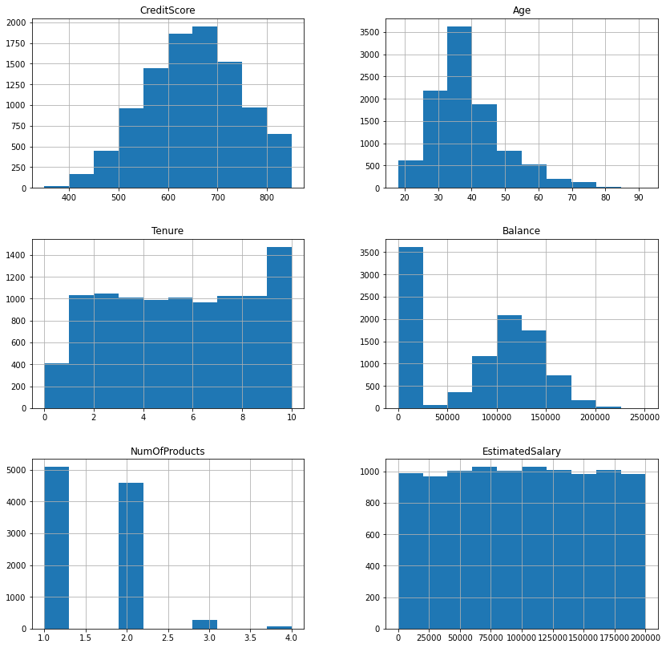

```python
# creating histograms
data[numerical_cols].hist(figsize=(14, 14))
plt.show()
```

```python
# function to create labeled barplots


def labeled_barplot(data, feature, perc=False, n=None):
    """
    Barplot with percentage at the top

    data: dataframe
    feature: dataframe column
    perc: whether to display percentages instead of count (default is False)
    n: displays the top n category levels (default is None, i.e., display all levels)
    """

    total = len(data[feature])  # length of the column
    count = data[feature].nunique()
    if n is None:
        plt.figure(figsize=(count + 1, 5))
    else:
        plt.figure(figsize=(n + 1, 5))

    plt.xticks(rotation=90, fontsize=15)
    ax = sns.countplot(
        data=data,
        x=feature,
        palette="Paired",
        order=data[feature].value_counts().index[:n].sort_values(),
    )

    for p in ax.patches:
        if perc == True:
            label = "{:.1f}%".format(
                100 * p.get_height() / total
            )  # percentage of each class of the category
        else:
            label = p.get_height()  # count of each level of the category

        x = p.get_x() + p.get_width() / 2  # width of the plot
        y = p.get_height()  # height of the plot

        ax.annotate(
            label,
            (x, y),
            ha="center",
            va="center",
            size=12,
            xytext=(0, 5),
            textcoords="offset points",
        )  # annotate the percentage

    plt.show()  # show the plot
```

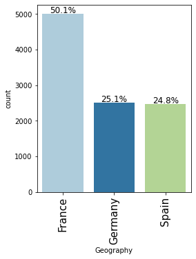

```python
labeled_barplot(data, "Geography", perc=True)
```

- France is leading the Geography around 50%., where as Spain and Germany are almost same (~25%)

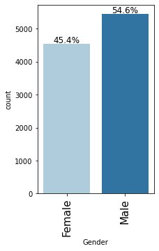

```python
labeled_barplot(data, "Gender", perc=True)
```

- Male (55%) count is dominated than female (45%) count

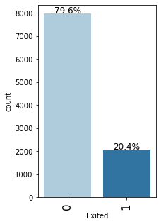

```python
labeled_barplot(data, "Exited", perc=True)
```

- Exited is a categorical variable that decides whether the customer left the bank within six months or not. It can take two values
- 0=No ( Customer did not leave the bank ) which is around 80%
- 1=Yes ( Customer left the bank ), which is around 20%.

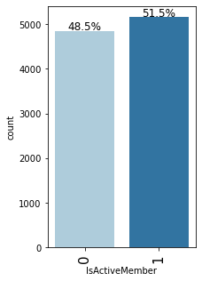

```python
labeled_barplot(data, "IsActiveMember", perc=True)
```

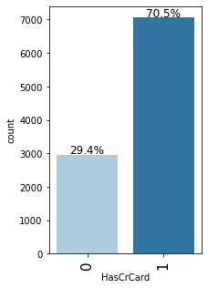

```python
labeled_barplot(data, "HasCrCard", perc=True)
```

- Though IsActiveMember and HasCrCard are true/false types, considering as cat columns
- About 52% are active members vers 48% not active.
- About 71% customers are having HasCrCard compared to 30%.

```python
# function to plot a boxplot and a histogram along the same scale.


def histogram_boxplot(data, feature, figsize=(12, 7), kde=False, bins=None):
    """
    Boxplot and histogram combined

    data: dataframe
    feature: dataframe column
    figsize: size of figure (default (12,7))
    kde: whether to show the density curve (default False)
    bins: number of bins for histogram (default None)
    """
    f2, (ax_box2, ax_hist2) = plt.subplots(
        nrows=2,  # Number of rows of the subplot grid= 2
        sharex=True,  # x-axis will be shared among all subplots
        gridspec_kw={"height_ratios": (0.25, 0.75)},
        figsize=figsize,
    )  # creating the 2 subplots
    sns.boxplot(
        data=data, x=feature, ax=ax_box2, showmeans=True, color="violet"
    )  # boxplot will be created and a star will indicate the mean value of the column
    sns.histplot(
        data=data, x=feature, kde=kde, ax=ax_hist2, bins=bins, palette="winter"
    ) if bins else sns.histplot(
        data=data, x=feature, kde=kde, ax=ax_hist2
    )  # For histogram
    ax_hist2.axvline(
        data[feature].mean(), color="green", linestyle="--"
    )  # Add mean to the histogram
    ax_hist2.axvline(
        data[feature].median(), color="black", linestyle="-"
    )  # Add median to the histogram
```

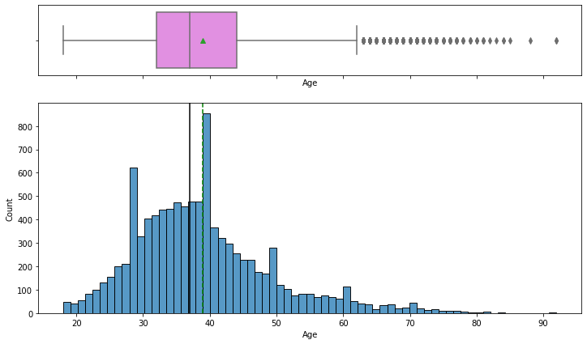

```python
histogram_boxplot(data, "Age")
```

- As I mentioned above, age is rightly skewed.

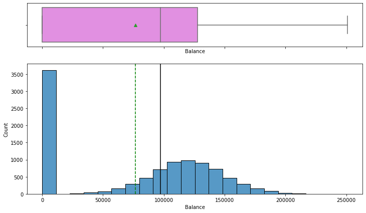

```python
histogram_boxplot(data, "Balance")
```

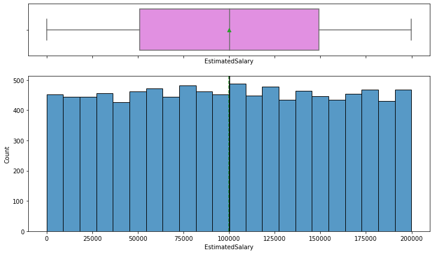

```python
histogram_boxplot(data, "EstimatedSalary")
```

- EsitmatedSalary is evenly distributed. It may be okay to drop it.

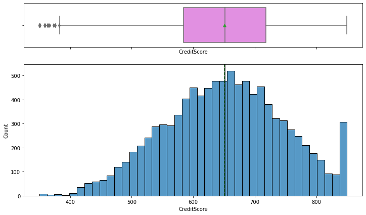

```python
histogram_boxplot(data, "CreditScore")
```

- Credit score is slightly negatvely (left side) skewed, though it apeears normally distributed.

### Bivariate analysis

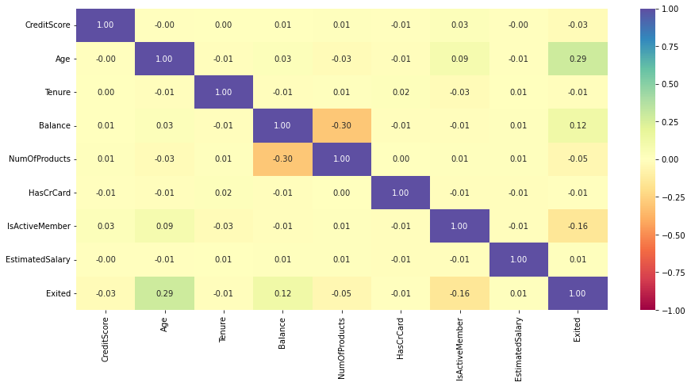

```python
plt.figure(figsize=(15, 7))
sns.heatmap(data.corr(), annot=True, vmin=-1, vmax=1, fmt=".2f", cmap="Spectral")
plt.show()
```

- There is not significant correlation between any two columns
- However Age and dependent variable (Exited) are slightly corrlated (.29)

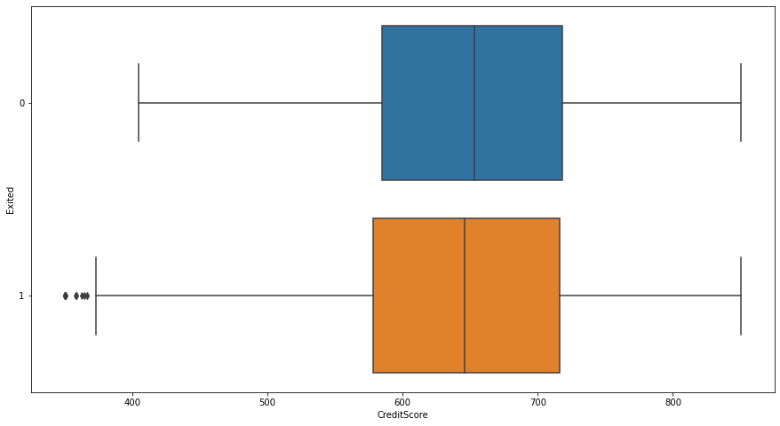

```python
plt.figure(figsize=(15, 8))
a = sns.boxplot(
    x="CreditScore",
    y="Exited",
    data=data.sort_values("Exited", ascending=False),
    orient="h",
)
```

- Both Exited 0 and 1 almost all are having similar median.

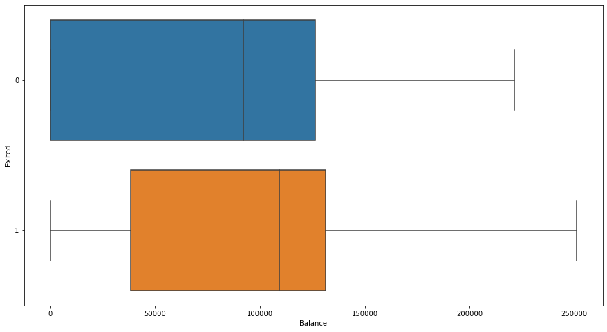

```python
plt.figure(figsize=(15, 8))
a = sns.boxplot(
    x="Balance",
    y="Exited",
    data=data.sort_values("Exited", ascending=False),
    orient="h",
)
```

- Customers who are having balance about 50k left the bank
- Bank should focus on these customers there is about 50 % of customer who are in that range (exited = 0)
- They may leave the bank , if bank do not focus on this group and find why they are leaving.

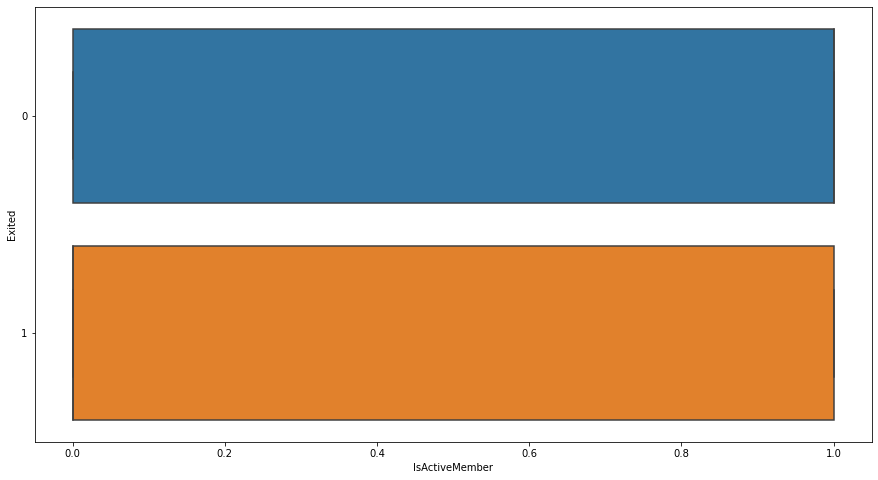

```python
plt.figure(figsize=(15, 8))
a = sns.boxplot(
    x="IsActiveMember",
    y="Exited",
    data=data.sort_values("Exited", ascending=False),
    orient="h",
)
```

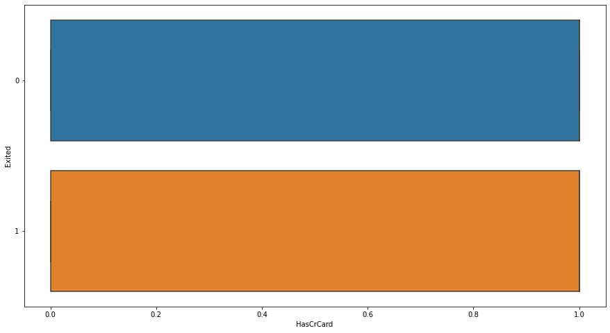

```python
plt.figure(figsize=(15, 8))
a = sns.boxplot(
    x="HasCrCard",
    y="Exited",
    data=data.sort_values("Exited", ascending=False),
    orient="h",
)
```

- Customers exited equally if there are HasCrCred or not.

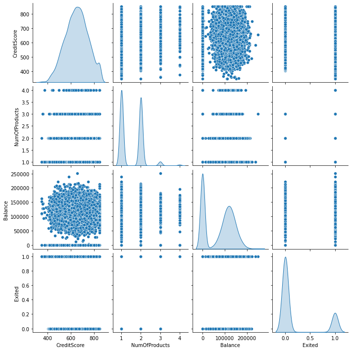

```python
sns.pairplot(
    data[["Geography", "CreditScore", "NumOfProducts", "Balance", "Exited"]],
    diag_kind="kde",
)
```

#### Observations

##### Data preprocessing - Feature engineering

###### Missing value treatment

- Already mentioned no missing values in the given dataset.

##### Outlier Identification and approach

```python
# finding customers who are more than 85  years old
data[(data.Age >= 85)]["Age"].count()
```

```
4
```

```python
data[(data.Age >= 85)]
```

|  | CreditScore | Geography | Gender | Age | Tenure | Balance | NumOfProducts | HasCrCard | IsActiveMember | EstimatedSalary | Exited |
| --- | --- | --- | --- | --- | --- | --- | --- | --- | --- | --- | --- |
| 2458 | 513 | Spain | Male | 88 | 10 | 0.00 | 2 | 1 | 1 | 52952.24 | 0 |
| 3033 | 787 | France | Female | 85 | 10 | 0.00 | 2 | 1 | 1 | 116537.96 | 0 |
| 6443 | 753 | France | Male | 92 | 3 | 121513.31 | 1 | 0 | 1 | 195563.99 | 0 |
| 6759 | 705 | France | Male | 92 | 1 | 126076.24 | 2 | 1 | 1 | 34436.83 | 0 |

```python
# To delete Customer  rows who are above 92 years old.
data.drop(data.index[df["Age"] == 92], inplace=True)
```

```python
# Checking after deletion
data[(data.Age >= 85)]
```

|  | CreditScore | Geography | Gender | Age | Tenure | Balance | NumOfProducts | HasCrCard | IsActiveMember | EstimatedSalary | Exited |
| --- | --- | --- | --- | --- | --- | --- | --- | --- | --- | --- | --- |
| 2458 | 513 | Spain | Male | 88 | 10 | 0.0 | 2 | 1 | 1 | 52952.24 | 0 |
| 3033 | 787 | France | Female | 85 | 10 | 0.0 | 2 | 1 | 1 | 116537.96 | 0 |

```python
# finding customers whose credit score is more than or equal to 850
data[(data.CreditScore >= 850)]
```

|  | CreditScore | Geography | Gender | Age | Tenure | Balance | NumOfProducts | HasCrCard | IsActiveMember | EstimatedSalary | Exited |
| --- | --- | --- | --- | --- | --- | --- | --- | --- | --- | --- | --- |
| 4 | 850 | Spain | Female | 43 | 2 | 125510.82 | 1 | 1 | 1 | 79084.10 | 0 |
| 38 | 850 | France | Male | 36 | 7 | 0.00 | 1 | 1 | 1 | 40812.90 | 0 |
| 180 | 850 | Spain | Female | 45 | 2 | 122311.21 | 1 | 1 | 1 | 19482.50 | 0 |
| 200 | 850 | Spain | Male | 30 | 2 | 141040.01 | 1 | 1 | 1 | 5978.20 | 0 |
| 223 | 850 | France | Male | 33 | 10 | 0.00 | 1 | 1 | 0 | 4861.72 | 1 |
| ... | ... | ... | ... | ... | ... | ... | ... | ... | ... | ... | ... |
| 9581 | 850 | France | Female | 28 | 9 | 0.00 | 2 | 1 | 1 | 164864.67 | 0 |
| 9646 | 850 | Spain | Male | 71 | 10 | 69608.14 | 1 | 1 | 0 | 97893.40 | 1 |
| 9688 | 850 | France | Male | 68 | 5 | 169445.40 | 1 | 1 | 1 | 186335.07 | 0 |
| 9931 | 850 | France | Female | 34 | 6 | 101266.51 | 1 | 1 | 0 | 33501.98 | 0 |
| 9949 | 850 | France | Female | 47 | 9 | 137301.87 | 1 | 1 | 0 | 44351.77 | 0 |

233 rows × 11 columns

- About 230 customers who have 850 creditscore means it is not an outlier. It represents market data. Not going to take any action

```python
# finding customers whose balance is more than 210K
data[(data.Balance >= 200000)]["Balance"].count()
```

```
34
```

- About 34 cutomers are having more than 200K balance, it represents the market trend. Not taking any action on outliers.
- I like to see how many are left bank who are having more than 100K balance

```python
# finding customers whose balance is more than 100K
data[(data.Balance >= 100000) & (data.Exited == 1)]
```

|  | CreditScore | Geography | Gender | Age | Tenure | Balance | NumOfProducts | HasCrCard | IsActiveMember | EstimatedSalary | Exited |
| --- | --- | --- | --- | --- | --- | --- | --- | --- | --- | --- | --- |
| 2 | 502 | France | Female | 42 | 8 | 159660.80 | 3 | 1 | 0 | 113931.57 | 1 |
| 5 | 645 | Spain | Male | 44 | 8 | 113755.78 | 2 | 1 | 0 | 149756.71 | 1 |
| 7 | 376 | Germany | Female | 29 | 4 | 115046.74 | 4 | 1 | 0 | 119346.88 | 1 |
| 16 | 653 | Germany | Male | 58 | 1 | 132602.88 | 1 | 1 | 0 | 5097.67 | 1 |
| 35 | 475 | France | Female | 45 | 0 | 134264.04 | 1 | 1 | 0 | 27822.99 | 1 |
| ... | ... | ... | ... | ... | ... | ... | ... | ... | ... | ... | ... |
| 9934 | 692 | Germany | Female | 43 | 10 | 118588.83 | 1 | 1 | 1 | 161241.65 | 1 |
| 9960 | 795 | Germany | Female | 33 | 9 | 104552.72 | 1 | 1 | 1 | 120853.83 | 1 |
| 9975 | 610 | Germany | Male | 50 | 1 | 113957.01 | 2 | 1 | 0 | 196526.55 | 1 |
| 9981 | 498 | Germany | Male | 42 | 3 | 152039.70 | 1 | 1 | 1 | 53445.17 | 1 |
| 9982 | 655 | Germany | Female | 46 | 7 | 137145.12 | 1 | 1 | 0 | 115146.40 | 1 |

1211 rows × 11 columns

- About 1200 cutomers are having more than 100K balance, left the bank and move to other bank. Let me see how many are having 100K balance and still with the bank.

```python
# finding customers whose balance is more than 100K
data[(data.Balance >= 100000) & (data.Exited == 0)]
```

|  | CreditScore | Geography | Gender | Age | Tenure | Balance | NumOfProducts | HasCrCard | IsActiveMember | EstimatedSalary | Exited |
| --- | --- | --- | --- | --- | --- | --- | --- | --- | --- | --- | --- |
| 4 | 850 | Spain | Female | 43 | 2 | 125510.82 | 1 | 1 | 1 | 79084.10 | 0 |
| 8 | 501 | France | Male | 44 | 4 | 142051.07 | 2 | 0 | 1 | 74940.50 | 0 |
| 9 | 684 | France | Male | 27 | 2 | 134603.88 | 1 | 1 | 1 | 71725.73 | 0 |
| 10 | 528 | France | Male | 31 | 6 | 102016.72 | 2 | 0 | 0 | 80181.12 | 0 |
| 15 | 616 | Germany | Male | 45 | 3 | 143129.41 | 2 | 0 | 1 | 64327.26 | 0 |
| ... | ... | ... | ... | ... | ... | ... | ... | ... | ... | ... | ... |
| 9985 | 659 | France | Male | 36 | 6 | 123841.49 | 2 | 1 | 0 | 96833.00 | 0 |
| 9986 | 673 | Germany | Male | 47 | 1 | 183579.54 | 2 | 0 | 1 | 34047.54 | 0 |
| 9987 | 606 | Spain | Male | 30 | 8 | 180307.73 | 2 | 1 | 1 | 1914.41 | 0 |
| 9993 | 644 | France | Male | 28 | 7 | 155060.41 | 1 | 1 | 0 | 29179.52 | 0 |
| 9999 | 792 | France | Female | 28 | 4 | 130142.79 | 1 | 1 | 0 | 38190.78 | 0 |

3586 rows × 11 columns

```python
data.info()
```

```
<class 'pandas.core.frame.DataFrame'>
Int64Index: 9998 entries, 0 to 9999
Data columns (total 11 columns):
 #   Column           Non-Null Count  Dtype
---  ------           --------------  -----
 0   CreditScore      9998 non-null   int64
 1   Geography        9998 non-null   object
 2   Gender           9998 non-null   object
 3   Age              9998 non-null   int64
 4   Tenure           9998 non-null   int64
 5   Balance          9998 non-null   float64
 6   NumOfProducts    9998 non-null   int64
 7   HasCrCard        9998 non-null   int64
 8   IsActiveMember   9998 non-null   int64
 9   EstimatedSalary  9998 non-null   float64
 10  Exited           9998 non-null   int64
dtypes: float64(2), int64(7), object(2)
memory usage: 937.3+ KB
```

- Since 'EsitmatedSalary' is not having much impact, it is not correlated (0.01) with the Exited (dependent variable), I opt to remove this column.

```python
# Dropping EsitmatedSalary variable
data.drop(["EstimatedSalary"], axis=1, inplace=True)
```

#### Summary of EDA

##### Data Description:

- Target variable 'Exited': About 80% are existing customers. 20% are Attrited customers.
- There are no missing values in the dataset.
- Discussed in length about other columns in the above section.

#### Data Cleaning:

- Both RowNumber, CustomerId are unique variables so decided to dropped from the data.
- Surname is also have no impact on building models, hence decided to remove it.
- After careful consideration, EstimatedSalary column is also removed.

#### Observations from EDA:

```python
# getting the features and labels and finally splitting the test and train data.
X = data.drop("Exited", axis=1)
Y = data["Exited"]
```

```python
# Splitting the training and test set
X_train, X_test, y_train, y_test = train_test_split(
    X, Y, test_size=0.30, random_state=1, shuffle=True
)
```

```python
##Splitting Independent and dependent variable in X and Y respectively
X = data.drop(["Exited"], axis=1)
Y = data[["Exited"]]

print(X.shape)
print(Y.shape)
print(type(X))
```

```
(9998, 9)
(9998, 1)
<class 'pandas.core.frame.DataFrame'>
```

```python
# Checking the shape of train and test data
print(X_train.shape)
print(X_test.shape)
```

```
(6998, 9)
(3000, 9)
```

```python
# Splitting the dataset into the Training and Testing set.
X_big, X_test, y_big, y_test = train_test_split(
    X, Y, test_size=0.1, random_state=5, stratify=Y, shuffle=True
)
```

```python
# Splitting the dataset into the Training and validation set.
X_train, X_val, y_train, y_val = train_test_split(
    X_big, y_big, test_size=0.3, random_state=5, stratify=y_big, shuffle=True
)
```

```python
X_train.head()
```

|  | CreditScore | Geography | Gender | Age | Tenure | Balance | NumOfProducts | HasCrCard | IsActiveMember |
| --- | --- | --- | --- | --- | --- | --- | --- | --- | --- |
| 6404 | 649 | Spain | Female | 49 | 2 | 0.00 | 1 | 1 | 0 |
| 4936 | 580 | Germany | Male | 24 | 1 | 133811.78 | 1 | 1 | 0 |
| 1651 | 634 | Spain | Male | 31 | 9 | 108632.48 | 1 | 1 | 1 |
| 5089 | 688 | Germany | Male | 45 | 9 | 103399.87 | 1 | 0 | 0 |
| 3670 | 850 | France | Male | 28 | 4 | 0.00 | 2 | 1 | 1 |

##### Normalizing

```python
# Number of Int columns after removing the estimatedsalary column
num_cols = [
    "CreditScore",
    "Age",
    "Tenure",
    "Balance",
    "NumOfProducts",
]
```

- The numerical columns present in this dataset are having different units, so scaling would help them all be in the same range.

```python
# Scaling the data
sc = StandardScaler()
temp = sc.fit(X_train[num_cols])
X_train[num_cols] = temp.transform(X_train[num_cols])
X_test[num_cols] = temp.transform(X_test[num_cols])
X_val[num_cols] = temp.transform(X_val[num_cols])
```

```python
# Checking the data after scaling is done.
X_train.head()
```

|  | CreditScore | Geography | Gender | Age | Tenure | Balance | NumOfProducts | HasCrCard | IsActiveMember |
| --- | --- | --- | --- | --- | --- | --- | --- | --- | --- |
| 6404 | -0.007201 | Spain | Female | 0.935098 | -1.050299 | -1.212093 | -0.914502 | 1 | 0 |
| 4936 | -0.718906 | Germany | Male | -1.420563 | -1.395574 | 0.926269 | -0.914502 | 1 | 0 |
| 1651 | -0.161920 | Spain | Male | -0.760978 | 1.366628 | 0.523894 | -0.914502 | 1 | 1 |
| 5089 | 0.395067 | Germany | Male | 0.558192 | 1.366628 | 0.440275 | -0.914502 | 0 | 0 |
| 3670 | 2.066027 | France | Male | -1.043657 | -0.359748 | -1.212093 | 0.774511 | 1 | 1 |

#### Categorical Features Encoding

- Both Geography and Gender are categorical columns, To utilise these columns, I convert them to numerical and going to apply One-hot Encoding technique.

```python
# Using pd.get dummies to encode the categorical columns in the data
X_train = pd.get_dummies(X_train, columns=cat_cols, drop_first=True)
X_test = pd.get_dummies(X_test, columns=cat_cols, drop_first=True)
X_val = pd.get_dummies(X_val, columns=cat_cols, drop_first=True)
```

```python
# after one-hot encoding technique applied.
X_train.head()
```

|  | CreditScore | Age | Tenure | Balance | NumOfProducts | HasCrCard | IsActiveMember | Geography_Germany | Geography_Spain | Gender_Male |
| --- | --- | --- | --- | --- | --- | --- | --- | --- | --- | --- |
| 6404 | -0.007201 | 0.935098 | -1.050299 | -1.212093 | -0.914502 | 1 | 0 | 0 | 1 | 0 |
| 4936 | -0.718906 | -1.420563 | -1.395574 | 0.926269 | -0.914502 | 1 | 0 | 1 | 0 | 1 |
| 1651 | -0.161920 | -0.760978 | 1.366628 | 0.523894 | -0.914502 | 1 | 1 | 0 | 1 | 1 |
| 5089 | 0.395067 | 0.558192 | 1.366628 | 0.440275 | -0.914502 | 0 | 0 | 1 | 0 | 1 |
| 3670 | 2.066027 | -1.043657 | -0.359748 | -1.212093 | 0.774511 | 1 | 1 | 0 | 0 | 1 |

```python
# Checking the shape
print(X_train.shape)
print(X_val.shape)
print(y_train.shape)
print(y_val.shape)
print(X_test.shape)
print(y_test.shape)
```

```
(6298, 10)
(2700, 10)
(6298, 1)
(2700, 1)
(1000, 10)
(1000, 1)
```

#### Model building

##### Random Forest

```python
from sklearn.ensemble import RandomForestClassifier
```

```python
random_forest = RandomForestClassifier(n_estimators=100)
```

```python
# Pandas Series.ravel() function returns the flattened underlying data as an ndarray.
random_forest.fit(
    X_train, y_train.values.ravel()
)  # np.ravel() Return a contiguous flattened array
```

```
RandomForestClassifier()
```

```python
y_pred = random_forest.predict(X_val)
```

```python
random_forest.score(X_val, y_val)
```

```
0.8655555555555555
```

```python
def make_confusion_matrix(
    cf,
    group_names=None,
    categories="auto",
    count=True,
    percent=True,
    cbar=True,
    xyticks=True,
    xyplotlabels=True,
    sum_stats=True,
    figsize=None,
    cmap="Blues",
    title=None,
):
    """
    This function will make a pretty plot of an sklearn Confusion Matrix cm using a Seaborn heatmap visualization.
    Arguments
    """

    # CODE TO GENERATE TEXT INSIDE EACH SQUARE
    blanks = ["" for i in range(cf.size)]

    if group_names and len(group_names) == cf.size:
        group_labels = ["{}\n".format(value) for value in group_names]
    else:
        group_labels = blanks

    if count:
        group_counts = ["{0:0.0f}\n".format(value) for value in cf.flatten()]
    else:
        group_counts = blanks

    if percent:
        group_percentages = [
            "{0:.2%}".format(value) for value in cf.flatten() / np.sum(cf)
        ]
    else:
        group_percentages = blanks

    box_labels = [
        f"{v1}{v2}{v3}".strip()
        for v1, v2, v3 in zip(group_labels, group_counts, group_percentages)
    ]
    box_labels = np.asarray(box_labels).reshape(cf.shape[0], cf.shape[1])

    # CODE TO GENERATE SUMMARY STATISTICS & TEXT FOR SUMMARY STATS
    if sum_stats:
        # Accuracy is sum of diagonal divided by total observations
        accuracy = np.trace(cf) / float(np.sum(cf))

        # if it is a binary confusion matrix, show some more stats
        if len(cf) == 2:
            # Metrics for Binary Confusion Matrices
            precision = cf[1, 1] / sum(cf[:, 1])
            recall = cf[1, 1] / sum(cf[1, :])
            f1_score = 2 * precision * recall / (precision + recall)
            stats_text = "\n\nAccuracy={:0.3f}\nPrecision={:0.3f}\nRecall={:0.3f}\nF1 Score={:0.3f}".format(
                accuracy, precision, recall, f1_score
            )
        else:
            stats_text = "\n\nAccuracy={:0.3f}".format(accuracy)
    else:
        stats_text = ""

    # SET FIGURE PARAMETERS ACCORDING TO OTHER ARGUMENTS
    if figsize == None:
        # Get default figure size if not set
        figsize = plt.rcParams.get("figure.figsize")

    if xyticks == False:
        # Do not show categories if xyticks is False
        categories = False

    # MAKE THE HEATMAP VISUALIZATION
    plt.figure(figsize=figsize)
    sns.heatmap(
        cf,
        annot=box_labels,
        fmt="",
        cmap=cmap,
        cbar=cbar,
        xticklabels=categories,
        yticklabels=categories,
    )

    if xyplotlabels:
        plt.ylabel("True label")
        plt.xlabel("Predicted label" + stats_text)
    else:
        plt.xlabel(stats_text)

    if title:
        plt.title(title)
```

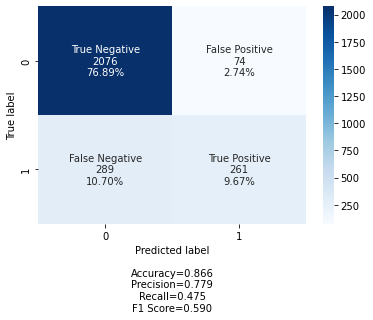

```python
cm = confusion_matrix(y_val, y_pred)
labels = ["True Negative", "False Positive", "False Negative", "True Positive"]
make_confusion_matrix(
    cm,
    group_names=labels,
    # categories=categories,
    cmap="Blues",
)
```

### Model evaluation criterion

#### Model can make wrong predictions as:

- Predicting a customer leaving and joining another service provider (churn) but not happend (not left the company)
- Predicting a customer not leaving and joining another service provider (churn) but happend (lef the company)

#### Which case is more important?

- Predicting a customer not leaving and joining another service provider (churn) but happend, which incur a loss to the bank.

#### How to reduce this loss i.e need to reduce False Negative?

- Company would want Recall to be maximized, greater the Recall higher the chances of minimizing false Negative. Hence, the focus should be on increasing Recall or minimizing the false Negative or in other words identifying the True Positive(i.e. Class 1) so that the Company can identify the fraud transaction.

#### Explore Neural Network models

##### Deep neural network

###### Model-1

- I use a simple NN made of 3 fully-connected layers with ReLu activation. The NN takes a vector of length 10 as input. This represents the information related to each transactions, ie each line with 10 columns from the dataset. For each transaction, the final layer will output a probability distribution (sigmoid activation function) and classify either as not exited (0) or exited (1).
- I used SGD technique as an optimizer.

```python
# Fixing the seed for random number generators
np.random.seed(42)

import random

random.seed(42)

tf.random.set_seed(42)
```

```python
# to ignore the following issue, I set enviroment
"""tensorflow/core/platform/cpu_feature_guard.cc:193] This TensorFlow binary is
#optimized with oneAPI Deep Neural Network Library (oneDNN) to use the following CPU instructions in performance-critical operations:  AVX2 AVX512F AVX512_VNNI FMA
#To enable them in other operations, rebuild TensorFlow with the appropriate compiler flags"""

os.environ["TF_CPP_MIN_LOG_LEVEL"] = "2"
```

#### Adding layers [layers and activations]

- Keras layers can be added to the model
- Adding layers are like stacking lego blocks one by one
- It should be noted that as this is a classification problem, sigmoid layer (softmax for multi-class problems) should be added

```python
# We will be adding the layers sequentially
model_1 = Sequential()

# Adding input layer with 64 neurons, relu as activation function and, he_uniform as weight initializer.
model_1.add(
    Dense(64, activation="relu", kernel_initializer="he_uniform", input_shape=(10,))
)
# Adding the first hidden layer with 32 neurons, relu as activation function and, he_uniform as weight initializer
model_1.add(Dense(32, activation="relu", kernel_initializer="he_uniform"))
# Adding the second hidden layer with 32 neurons, relu as activation function and, he_uniform as weight initializer
model_1.add(Dense(32, activation="relu", kernel_initializer="he_uniform"))

# I use the sigmoid because this is classification problem
model_1.add(Dense(1, activation="sigmoid"))
```

#### Model compile [optimizers and loss functions]

- Keras model should be "compiled" prior to training
- Types of loss (function) and optimizer should be designated
- Finally, printing the summary of the model

```python
# Compliling the model with binary crossentropy as loss, SGD as optimizer and accuracy as metrics
model_1.compile(loss="binary_crossentropy", optimizer="SGD", metrics=["accuracy"])
# Printing the summary of the model
model_1.summary()
```

```
Model: "sequential"
_________________________________________________________________
 Layer (type)                Output Shape              Param #
=================================================================
 dense (Dense)               (None, 64)                704

 dense_1 (Dense)             (None, 32)                2080

 dense_2 (Dense)             (None, 32)                1056

 dense_3 (Dense)             (None, 1)                 33

=================================================================
Total params: 3,873
Trainable params: 3,873
Non-trainable params: 0
_________________________________________________________________
```

### Observations

- The summary of the model shows each layer's name, type, output shape, and the number of parameters at that particular layer.
- It also shows the total number of trainable and non-trainable parameters in the model. A parameter whose value is learned while training the model is called a trainable parameter otherwise it is called a non-trainable parameter.
- In the first layer total parameters are calculated by the number of neurons in the hidden layer multiplied by the number of variables fed to neural networks plus bias. (10*64)+64 = 704
- In the next layer the parameters are calculated by the number of outputs from the previous layer multiplied by the number of neurons in the second layer plus bias. (64*32)+32 =2080
- Rest of them we calculate in the same way (32*32)+32 = 1056
- for output layer (32*1)+1 = 33
- Training the model

```python
# Fitting the model on train data
history_1 = model_1.fit(
    X_train, y_train, validation_data=(X_val, y_val), epochs=50, verbose=2
)
# history = model.fit(X_train, y_train, validation_data=(X_val, y_val_scale), epochs=50)
```

```
197/197 - 1s - loss: 0.4895 - accuracy: 0.7974 - val_loss: 0.4591 - val_accuracy: 0.8074 - 1s/epoch - 5ms/step
197/197 - 0s - loss: 0.4441 - accuracy: 0.8115 - val_loss: 0.4380 - val_accuracy: 0.8137 - 296ms/epoch - 2ms/step
197/197 - 0s - loss: 0.4276 - accuracy: 0.8163 - val_loss: 0.4272 - val_accuracy: 0.8193 - 277ms/epoch - 1ms/step
197/197 - 0s - loss: 0.4168 - accuracy: 0.8222 - val_loss: 0.4199 - val_accuracy: 0.8274 - 231ms/epoch - 1ms/step
197/197 - 0s - loss: 0.4089 - accuracy: 0.8260 - val_loss: 0.4142 - val_accuracy: 0.8296 - 241ms/epoch - 1ms/step
197/197 - 0s - loss: 0.4025 - accuracy: 0.8287 - val_loss: 0.4081 - val_accuracy: 0.8348 - 255ms/epoch - 1ms/step
197/197 - 0s - loss: 0.3967 - accuracy: 0.8317 - val_loss: 0.4065 - val_accuracy: 0.8307 - 255ms/epoch - 1ms/step
197/197 - 0s - loss: 0.3921 - accuracy: 0.8365 - val_loss: 0.3991 - val_accuracy: 0.8393 - 258ms/epoch - 1ms/step
197/197 - 0s - loss: 0.3872 - accuracy: 0.8399 - val_loss: 0.3971 - val_accuracy: 0.8381 - 254ms/epoch - 1ms/step
197/197 - 0s - loss: 0.3831 - accuracy: 0.8395 - val_loss: 0.3916 - val_accuracy: 0.8419 - 236ms/epoch - 1ms/step
197/197 - 0s - loss: 0.3787 - accuracy: 0.8431 - val_loss: 0.3929 - val_accuracy: 0.8367 - 279ms/epoch - 1ms/step
197/197 - 0s - loss: 0.3754 - accuracy: 0.8458 - val_loss: 0.3861 - val_accuracy: 0.8407 - 301ms/epoch - 2ms/step
197/197 - 0s - loss: 0.3713 - accuracy: 0.8474 - val_loss: 0.3819 - val_accuracy: 0.8481 - 265ms/epoch - 1ms/step
197/197 - 0s - loss: 0.3687 - accuracy: 0.8477 - val_loss: 0.3810 - val_accuracy: 0.8452 - 243ms/epoch - 1ms/step
197/197 - 0s - loss: 0.3654 - accuracy: 0.8520 - val_loss: 0.3770 - val_accuracy: 0.8481 - 300ms/epoch - 2ms/step
197/197 - 0s - loss: 0.3622 - accuracy: 0.8506 - val_loss: 0.3738 - val_accuracy: 0.8485 - 283ms/epoch - 1ms/step
197/197 - 0s - loss: 0.3598 - accuracy: 0.8517 - val_loss: 0.3740 - val_accuracy: 0.8437 - 239ms/epoch - 1ms/step
197/197 - 0s - loss: 0.3571 - accuracy: 0.8520 - val_loss: 0.3726 - val_accuracy: 0.8474 - 261ms/epoch - 1ms/step
197/197 - 0s - loss: 0.3551 - accuracy: 0.8554 - val_loss: 0.3686 - val_accuracy: 0.8519 - 254ms/epoch - 1ms/step
197/197 - 0s - loss: 0.3522 - accuracy: 0.8566 - val_loss: 0.3699 - val_accuracy: 0.8463 - 233ms/epoch - 1ms/step
197/197 - 0s - loss: 0.3514 - accuracy: 0.8581 - val_loss: 0.3651 - val_accuracy: 0.8522 - 352ms/epoch - 2ms/step
197/197 - 0s - loss: 0.3494 - accuracy: 0.8576 - val_loss: 0.3633 - val_accuracy: 0.8530 - 271ms/epoch - 1ms/step
197/197 - 0s - loss: 0.3471 - accuracy: 0.8593 - val_loss: 0.3701 - val_accuracy: 0.8478 - 294ms/epoch - 1ms/step
197/197 - 0s - loss: 0.3463 - accuracy: 0.8573 - val_loss: 0.3622 - val_accuracy: 0.8511 - 241ms/epoch - 1ms/step
197/197 - 0s - loss: 0.3450 - accuracy: 0.8584 - val_loss: 0.3612 - val_accuracy: 0.8511 - 271ms/epoch - 1ms/step
197/197 - 0s - loss: 0.3437 - accuracy: 0.8595 - val_loss: 0.3598 - val_accuracy: 0.8504 - 232ms/epoch - 1ms/step
197/197 - 0s - loss: 0.3422 - accuracy: 0.8590 - val_loss: 0.3595 - val_accuracy: 0.8548 - 241ms/epoch - 1ms/step
197/197 - 0s - loss: 0.3404 - accuracy: 0.8614 - val_loss: 0.3602 - val_accuracy: 0.8511 - 230ms/epoch - 1ms/step
197/197 - 0s - loss: 0.3400 - accuracy: 0.8604 - val_loss: 0.3575 - val_accuracy: 0.8515 - 226ms/epoch - 1ms/step
197/197 - 0s - loss: 0.3382 - accuracy: 0.8609 - val_loss: 0.3588 - val_accuracy: 0.8533 - 224ms/epoch - 1ms/step
197/197 - 0s - loss: 0.3375 - accuracy: 0.8615 - val_loss: 0.3597 - val_accuracy: 0.8493 - 221ms/epoch - 1ms/step
197/197 - 0s - loss: 0.3366 - accuracy: 0.8619 - val_loss: 0.3574 - val_accuracy: 0.8511 - 225ms/epoch - 1ms/step
197/197 - 0s - loss: 0.3358 - accuracy: 0.8617 - val_loss: 0.3584 - val_accuracy: 0.8504 - 228ms/epoch - 1ms/step
197/197 - 0s - loss: 0.3348 - accuracy: 0.8620 - val_loss: 0.3548 - val_accuracy: 0.8533 - 224ms/epoch - 1ms/step
197/197 - 0s - loss: 0.3341 - accuracy: 0.8625 - val_loss: 0.3550 - val_accuracy: 0.8504 - 304ms/epoch - 2ms/step
197/197 - 0s - loss: 0.3331 - accuracy: 0.8631 - val_loss: 0.3564 - val_accuracy: 0.8489 - 217ms/epoch - 1ms/step
197/197 - 0s - loss: 0.3329 - accuracy: 0.8607 - val_loss: 0.3540 - val_accuracy: 0.8519 - 347ms/epoch - 2ms/step
197/197 - 0s - loss: 0.3315 - accuracy: 0.8649 - val_loss: 0.3600 - val_accuracy: 0.8504 - 243ms/epoch - 1ms/step
197/197 - 0s - loss: 0.3304 - accuracy: 0.8647 - val_loss: 0.3585 - val_accuracy: 0.8511 - 284ms/epoch - 1ms/step
197/197 - 0s - loss: 0.3304 - accuracy: 0.8627 - val_loss: 0.3551 - val_accuracy: 0.8537 - 296ms/epoch - 2ms/step
197/197 - 0s - loss: 0.3289 - accuracy: 0.8628 - val_loss: 0.3537 - val_accuracy: 0.8544 - 288ms/epoch - 1ms/step
197/197 - 0s - loss: 0.3289 - accuracy: 0.8646 - val_loss: 0.3542 - val_accuracy: 0.8515 - 232ms/epoch - 1ms/step
197/197 - 0s - loss: 0.3279 - accuracy: 0.8665 - val_loss: 0.3557 - val_accuracy: 0.8507 - 241ms/epoch - 1ms/step
197/197 - 0s - loss: 0.3279 - accuracy: 0.8647 - val_loss: 0.3545 - val_accuracy: 0.8530 - 223ms/epoch - 1ms/step
197/197 - 0s - loss: 0.3270 - accuracy: 0.8673 - val_loss: 0.3520 - val_accuracy: 0.8511 - 221ms/epoch - 1ms/step
197/197 - 0s - loss: 0.3266 - accuracy: 0.8663 - val_loss: 0.3528 - val_accuracy: 0.8563 - 228ms/epoch - 1ms/step
197/197 - 0s - loss: 0.3258 - accuracy: 0.8658 - val_loss: 0.3532 - val_accuracy: 0.8522 - 215ms/epoch - 1ms/step
197/197 - 0s - loss: 0.3245 - accuracy: 0.8657 - val_loss: 0.3529 - val_accuracy: 0.8541 - 218ms/epoch - 1ms/step
197/197 - 0s - loss: 0.3240 - accuracy: 0.8649 - val_loss: 0.3540 - val_accuracy: 0.8544 - 217ms/epoch - 1ms/step
197/197 - 0s - loss: 0.3241 - accuracy: 0.8641 - val_loss: 0.3538 - val_accuracy: 0.8519 - 219ms/epoch - 1ms/step
```

- Plotting the train and validation loss

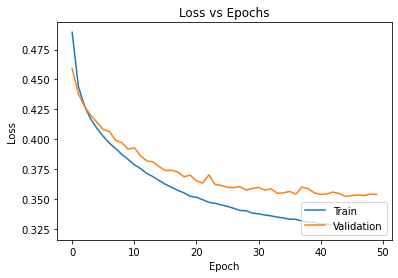

```python
plt.plot(history_1.history["loss"])

plt.plot(history_1.history["val_loss"])

plt.title("Loss vs Epochs")

plt.ylabel("Loss")

plt.xlabel("Epoch")

plt.legend(["Train", "Validation"], loc="lower right")

plt.show()
```

- Here the model seems to be overfitted, as the distance between the train curve and validation curve started increasing.

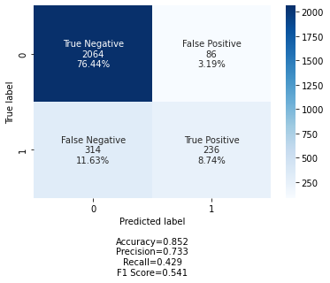

```python
## Confusion Matrix on validation test data
import seaborn as sn

y_pred1 = model_1.predict(X_val)
for i in range(len(y_val)):
    if y_pred1[i] > 0.5:
        y_pred1[i] = 1
    else:
        y_pred1[i] = 0


cm1 = confusion_matrix(y_val, y_pred1)
labels = ["True Negative", "False Positive", "False Negative", "True Positive"]
categories = ["Not_Fraud", "Fraud"]
make_confusion_matrix(
    cm1,
    group_names=labels,
    # categories=categories,
    cmap="Blues",
)
```

- The recall was not improved. False negatives gone up too. Going to experiment with different model.

##### Model-2

- I use a simple NN made of 3 fully-connected layers with ReLu activation. The NN takes a vector of length 10 as input. This represents the information related to each transactions, ie each line with 10 columns from the dataset. For each transaction, the final layer will output a probability distribution (sigmoid activation function) and classify either as not exited (0) or exited (1).
- This time, I used Adam optimizer with learning_rate=0.001

```python
# Clearing the backend
from tensorflow.keras import backend

backend.clear_session()
```

```python
# Fixing the seed for random number generators
np.random.seed(42)

import random

random.seed(42)

tf.random.set_seed(42)
```

```python
# We will be adding the layers sequentially
model_2 = Sequential()
# First hidden layer with 16 neurons and relu activation function, the input_shape tuple denotes number of independent variables
model_2.add(Dense(16, activation="relu", input_shape=(10,)))

# Second hidden layer with 24 neurons and relu activation function
model_2.add(Dense(24, activation="relu"))

# Second hidden layer with 24 neurons and relu activation function
model_2.add(Dense(24, activation="relu"))

# I use the sigmoid because I want probability outcomes
model_2.add(Dense(1, activation="sigmoid"))
```

```python
# Compliling the model with binary crossentropy as loss, Adam as optimizer and accuracy as metrics
model_2.compile(
    loss="binary_crossentropy",
    optimizer=tf.keras.optimizers.Adam(learning_rate=0.001),
    metrics=["accuracy"],
)
# Printing the summary of the model
model_2.summary()
```

```
Model: "sequential"
_________________________________________________________________
 Layer (type)                Output Shape              Param #
=================================================================
 dense (Dense)               (None, 16)                176

 dense_1 (Dense)             (None, 24)                408

 dense_2 (Dense)             (None, 24)                600

 dense_3 (Dense)             (None, 1)                 25

=================================================================
Total params: 1,209
Trainable params: 1,209
Non-trainable params: 0
_________________________________________________________________
```

#### Observations

- The summary of the model shows each layer's name, type, output shape, and the number of parameters at that particular layer.
- It also shows the total number of trainable and non-trainable parameters in the model. A parameter whose value is learned while training the model is called a trainable parameter otherwise it is called a non-trainable parameter.
- In the first layer total parameters are calculated by the number of neurons in the hidden layer multiplied by the number of variables fed to neural networks plus bias. (10*16)+16 = 176
- In the next layer the parameters are calculated by the number of outputs from the previous layer multiplied by the number of neurons in the second layer plus bias. (16*24)+24 = 408
- We can calculate for the rest of the layers in the same way.

```python
# Fitting the model on train data
history_2 = model_2.fit(
    X_train, y_train, validation_data=(X_val, y_val), epochs=100, verbose=2
)
```

```
197/197 - 1s - loss: 0.4841 - accuracy: 0.7964 - val_loss: 0.4289 - val_accuracy: 0.8037 - 766ms/epoch - 4ms/step
197/197 - 0s - loss: 0.4088 - accuracy: 0.8249 - val_loss: 0.3921 - val_accuracy: 0.8333 - 290ms/epoch - 1ms/step
197/197 - 0s - loss: 0.3731 - accuracy: 0.8474 - val_loss: 0.3670 - val_accuracy: 0.8456 - 256ms/epoch - 1ms/step
197/197 - 0s - loss: 0.3581 - accuracy: 0.8517 - val_loss: 0.3556 - val_accuracy: 0.8485 - 247ms/epoch - 1ms/step
197/197 - 0s - loss: 0.3503 - accuracy: 0.8550 - val_loss: 0.3531 - val_accuracy: 0.8474 - 252ms/epoch - 1ms/step
197/197 - 0s - loss: 0.3463 - accuracy: 0.8552 - val_loss: 0.3479 - val_accuracy: 0.8515 - 247ms/epoch - 1ms/step
197/197 - 0s - loss: 0.3440 - accuracy: 0.8596 - val_loss: 0.3476 - val_accuracy: 0.8552 - 250ms/epoch - 1ms/step
197/197 - 0s - loss: 0.3417 - accuracy: 0.8603 - val_loss: 0.3466 - val_accuracy: 0.8574 - 245ms/epoch - 1ms/step
197/197 - 0s - loss: 0.3393 - accuracy: 0.8636 - val_loss: 0.3444 - val_accuracy: 0.8533 - 268ms/epoch - 1ms/step
197/197 - 0s - loss: 0.3375 - accuracy: 0.8630 - val_loss: 0.3405 - val_accuracy: 0.8556 - 338ms/epoch - 2ms/step
197/197 - 0s - loss: 0.3365 - accuracy: 0.8631 - val_loss: 0.3420 - val_accuracy: 0.8589 - 364ms/epoch - 2ms/step
197/197 - 0s - loss: 0.3344 - accuracy: 0.8654 - val_loss: 0.3420 - val_accuracy: 0.8596 - 333ms/epoch - 2ms/step
197/197 - 0s - loss: 0.3333 - accuracy: 0.8661 - val_loss: 0.3395 - val_accuracy: 0.8552 - 248ms/epoch - 1ms/step
197/197 - 0s - loss: 0.3327 - accuracy: 0.8650 - val_loss: 0.3379 - val_accuracy: 0.8559 - 259ms/epoch - 1ms/step
197/197 - 0s - loss: 0.3303 - accuracy: 0.8654 - val_loss: 0.3462 - val_accuracy: 0.8567 - 284ms/epoch - 1ms/step
197/197 - 0s - loss: 0.3297 - accuracy: 0.8660 - val_loss: 0.3406 - val_accuracy: 0.8537 - 256ms/epoch - 1ms/step
197/197 - 0s - loss: 0.3302 - accuracy: 0.8663 - val_loss: 0.3381 - val_accuracy: 0.8567 - 258ms/epoch - 1ms/step
197/197 - 0s - loss: 0.3277 - accuracy: 0.8669 - val_loss: 0.3451 - val_accuracy: 0.8548 - 275ms/epoch - 1ms/step
197/197 - 0s - loss: 0.3285 - accuracy: 0.8669 - val_loss: 0.3389 - val_accuracy: 0.8559 - 286ms/epoch - 1ms/step
197/197 - 0s - loss: 0.3253 - accuracy: 0.8674 - val_loss: 0.3518 - val_accuracy: 0.8444 - 396ms/epoch - 2ms/step
197/197 - 0s - loss: 0.3251 - accuracy: 0.8690 - val_loss: 0.3375 - val_accuracy: 0.8585 - 264ms/epoch - 1ms/step
197/197 - 0s - loss: 0.3241 - accuracy: 0.8673 - val_loss: 0.3387 - val_accuracy: 0.8578 - 282ms/epoch - 1ms/step
197/197 - 0s - loss: 0.3244 - accuracy: 0.8690 - val_loss: 0.3413 - val_accuracy: 0.8541 - 263ms/epoch - 1ms/step
197/197 - 0s - loss: 0.3240 - accuracy: 0.8668 - val_loss: 0.3392 - val_accuracy: 0.8559 - 290ms/epoch - 1ms/step
197/197 - 0s - loss: 0.3220 - accuracy: 0.8700 - val_loss: 0.3393 - val_accuracy: 0.8563 - 266ms/epoch - 1ms/step
197/197 - 0s - loss: 0.3224 - accuracy: 0.8700 - val_loss: 0.3400 - val_accuracy: 0.8548 - 248ms/epoch - 1ms/step
197/197 - 0s - loss: 0.3214 - accuracy: 0.8692 - val_loss: 0.3448 - val_accuracy: 0.8485 - 288ms/epoch - 1ms/step
197/197 - 0s - loss: 0.3190 - accuracy: 0.8693 - val_loss: 0.3433 - val_accuracy: 0.8559 - 290ms/epoch - 1ms/step
197/197 - 0s - loss: 0.3193 - accuracy: 0.8681 - val_loss: 0.3391 - val_accuracy: 0.8563 - 264ms/epoch - 1ms/step
197/197 - 0s - loss: 0.3185 - accuracy: 0.8704 - val_loss: 0.3408 - val_accuracy: 0.8578 - 279ms/epoch - 1ms/step
197/197 - 0s - loss: 0.3177 - accuracy: 0.8715 - val_loss: 0.3411 - val_accuracy: 0.8548 - 278ms/epoch - 1ms/step
197/197 - 0s - loss: 0.3169 - accuracy: 0.8701 - val_loss: 0.3416 - val_accuracy: 0.8552 - 315ms/epoch - 2ms/step
197/197 - 0s - loss: 0.3169 - accuracy: 0.8725 - val_loss: 0.3417 - val_accuracy: 0.8570 - 316ms/epoch - 2ms/step
197/197 - 0s - loss: 0.3180 - accuracy: 0.8690 - val_loss: 0.3415 - val_accuracy: 0.8544 - 261ms/epoch - 1ms/step
197/197 - 0s - loss: 0.3156 - accuracy: 0.8701 - val_loss: 0.3408 - val_accuracy: 0.8581 - 248ms/epoch - 1ms/step
197/197 - 0s - loss: 0.3155 - accuracy: 0.8708 - val_loss: 0.3442 - val_accuracy: 0.8541 - 287ms/epoch - 1ms/step
197/197 - 0s - loss: 0.3152 - accuracy: 0.8711 - val_loss: 0.3419 - val_accuracy: 0.8533 - 355ms/epoch - 2ms/step
197/197 - 0s - loss: 0.3139 - accuracy: 0.8731 - val_loss: 0.3436 - val_accuracy: 0.8556 - 292ms/epoch - 1ms/step
197/197 - 0s - loss: 0.3138 - accuracy: 0.8720 - val_loss: 0.3475 - val_accuracy: 0.8548 - 309ms/epoch - 2ms/step
197/197 - 0s - loss: 0.3148 - accuracy: 0.8723 - val_loss: 0.3453 - val_accuracy: 0.8537 - 249ms/epoch - 1ms/step
```

[output cut: 45 more lines]

```
197/197 - 0s - loss: 0.2980 - accuracy: 0.8801 - val_loss: 0.3567 - val_accuracy: 0.8500 - 273ms/epoch - 1ms/step
197/197 - 0s - loss: 0.2979 - accuracy: 0.8803 - val_loss: 0.3593 - val_accuracy: 0.8515 - 313ms/epoch - 2ms/step
197/197 - 0s - loss: 0.2995 - accuracy: 0.8803 - val_loss: 0.3573 - val_accuracy: 0.8470 - 330ms/epoch - 2ms/step
197/197 - 0s - loss: 0.2982 - accuracy: 0.8817 - val_loss: 0.3590 - val_accuracy: 0.8470 - 279ms/epoch - 1ms/step
197/197 - 0s - loss: 0.2974 - accuracy: 0.8801 - val_loss: 0.3595 - val_accuracy: 0.8433 - 275ms/epoch - 1ms/step
197/197 - 0s - loss: 0.2974 - accuracy: 0.8785 - val_loss: 0.3622 - val_accuracy: 0.8437 - 335ms/epoch - 2ms/step
197/197 - 0s - loss: 0.2958 - accuracy: 0.8801 - val_loss: 0.3668 - val_accuracy: 0.8511 - 275ms/epoch - 1ms/step
197/197 - 0s - loss: 0.2964 - accuracy: 0.8796 - val_loss: 0.3557 - val_accuracy: 0.8459 - 320ms/epoch - 2ms/step
197/197 - 0s - loss: 0.2948 - accuracy: 0.8812 - val_loss: 0.3585 - val_accuracy: 0.8470 - 260ms/epoch - 1ms/step
197/197 - 0s - loss: 0.2966 - accuracy: 0.8784 - val_loss: 0.3599 - val_accuracy: 0.8456 - 293ms/epoch - 1ms/step
197/197 - 0s - loss: 0.2955 - accuracy: 0.8820 - val_loss: 0.3573 - val_accuracy: 0.8481 - 284ms/epoch - 1ms/step
197/197 - 0s - loss: 0.2948 - accuracy: 0.8822 - val_loss: 0.3604 - val_accuracy: 0.8522 - 257ms/epoch - 1ms/step
197/197 - 0s - loss: 0.2962 - accuracy: 0.8809 - val_loss: 0.3566 - val_accuracy: 0.8481 - 312ms/epoch - 2ms/step
197/197 - 0s - loss: 0.2937 - accuracy: 0.8811 - val_loss: 0.3700 - val_accuracy: 0.8489 - 272ms/epoch - 1ms/step
197/197 - 0s - loss: 0.2949 - accuracy: 0.8811 - val_loss: 0.3590 - val_accuracy: 0.8493 - 304ms/epoch - 2ms/step
```

- Plotting the train and validation loss

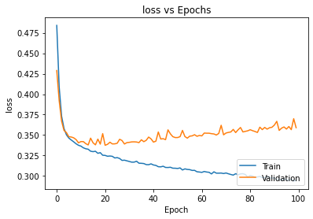

```python
plt.plot(history_2.history["loss"])

plt.plot(history_2.history["val_loss"])

plt.title("loss vs Epochs")

plt.ylabel("loss")

plt.xlabel("Epoch")

plt.legend(["Train", "Validation"], loc="lower right")

plt.show()
```

- Here the model seems to be overfitted significantly, as the distance between the train curve and validation curve started increasing noticeably.

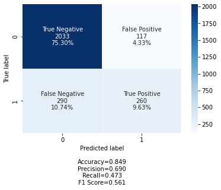

```python
## Confusion Matrix on validation data
import seaborn as sn

y_pred1 = model_2.predict(X_val)
for i in range(len(y_val)):
    if y_pred1[i] > 0.5:
        y_pred1[i] = 1
    else:
        y_pred1[i] = 0


cm2 = confusion_matrix(y_val, y_pred1)
labels = ["True Negative", "False Positive", "False Negative", "True Positive"]
categories = ["Not_Fraud", "Fraud"]
make_confusion_matrix(
    cm2,
    group_names=labels,
    # categories=categories,
    cmap="Blues",
)
```

```python
# Clearing the backend
from tensorflow.keras import backend

backend.clear_session()
```

```python
backend.clear_session()
# Fixing the seed for random number generators so that we can ensure we receive the same output everytime
np.random.seed(42)
import random

random.seed(42)
tf.random.set_seed(42)
```

```python
# initialize the model_3
model_3 = Sequential()
# This adds the input layer (by specifying input dimension) AND the first hidden layer (units)
model_3.add(
    Dense(units=16, input_dim=10, activation="relu")
)  # input of 29 columns as shown above
# hidden layer
model_3.add(Dense(units=24, activation="relu"))
# Adding Dropout to prevent overfitting
model_3.add(Dropout(0.5))
model_3.add(Dense(24, activation="relu"))
model_3.add(Dense(24, activation="relu"))
# Adding the output layer
# Notice that we do not need to specify input dim.
# we have an output of 1 node, which is the the desired dimensions of our output (fraud or not)
# We use the sigmoid because we want probability outcomes
model_3.add(Dense(1, activation="sigmoid"))  # binary classification fraudulent or not
```

```python
# Create optimizer with default learning rate
# Compile the model
model_3.compile(optimizer="adam", loss="binary_crossentropy", metrics=["accuracy"])
# Printing the summary of the model
model_3.summary()
```

```
Model: "sequential"
_________________________________________________________________
 Layer (type)                Output Shape              Param #
=================================================================
 dense (Dense)               (None, 16)                176

 dense_1 (Dense)             (None, 24)                408

 dropout (Dropout)           (None, 24)                0

 dense_2 (Dense)             (None, 24)                600

 dense_3 (Dense)             (None, 24)                600

 dense_4 (Dense)             (None, 1)                 25

=================================================================
Total params: 1,809
Trainable params: 1,809
Non-trainable params: 0
_________________________________________________________________
```

#### Observations

- The summary of the model shows each layer's name, type, output shape, and the number of parameters at that particular layer.
- It also shows the total number of trainable and non-trainable parameters in the model. A parameter whose value is learned while training the model is called a trainable parameter otherwise it is called a non-trainable parameter.

```python
# fitting the model
history = model_3.fit(
    X_train, y_train, batch_size=15, epochs=10, validation_data=(X_val, y_val)
)
```

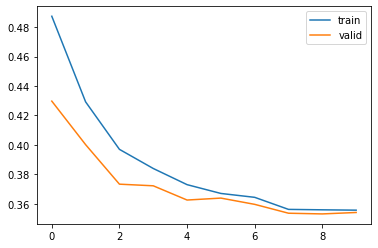

```python
# Capturing learning history per epoch
hist = pd.DataFrame(history.history)
hist["epoch"] = history.epoch

# Plotting accuracy at different epochs
plt.plot(hist["loss"])
plt.plot(hist["val_loss"])
plt.legend(("train", "valid"), loc=0)
```

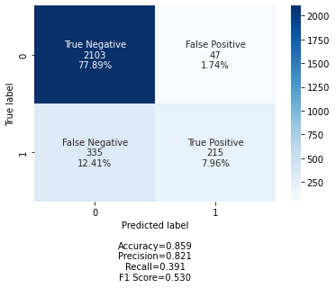

```python
## Confusion Matrix on unsee test set
import seaborn as sn

y_pred1 = model_3.predict(X_val)
for i in range(len(y_val)):
    if y_pred1[i] > 0.5:
        y_pred1[i] = 1
    else:
        y_pred1[i] = 0


cm3 = confusion_matrix(y_val, y_pred1)
labels = ["True Negative", "False Positive", "False Negative", "True Positive"]
# categories = [ 'Not_Fraud','Fraud']
make_confusion_matrix(
    cm3,
    group_names=labels,
    # categories=categories,
    cmap="Blues",
)
```

##### Model-4

- I'm going to use a NN made of 4 fully-connected layers with ReLu activation. The NN takes a vector of length 10 as input. This represents the information related to each transactions, ie each line with 10 columns from the dataset. For each transaction, the final layer will output a probability distribution (sigmoid activation function) and classify either as not exited (0) or exited (1).
- I'm goint to try the BatchNormalization technique and see if I can improve the metrics.
- And, I used Adam optimizer

```python
backend.clear_session()
# Fixing the seed for random number generators so that we can ensure we receive the same output everytime
np.random.seed(42)
import random

random.seed(42)
tf.random.set_seed(42)
```

```python
# Initializing the model
model_4 = Sequential()
# Adding input layer with 64 neurons, relu as activation function and, he_uniform as weight initializer.
model_4.add(
    Dense(64, activation="relu", kernel_initializer="he_uniform", input_shape=(10,))
)
# Adding the first hidden layer with 32 neurons, relu as activation function and, he_uniform as weight initializer
model_4.add(Dense(32, activation="relu", kernel_initializer="he_uniform"))
# Adding Batch Normalization
model_4.add(BatchNormalization())
# Adding the second hidden layer with 32 neurons, relu as activation function and, he_uniform as weight initializer
model_4.add(Dense(32, activation="relu", kernel_initializer="he_uniform"))
# We use the sigmoid because we want probability outcomes
model_4.add(Dense(1, activation="sigmoid"))  # binary classification fraudulent or not
```

```python
# Model summary
model_4.summary()
```

```
Model: "sequential"
_________________________________________________________________
 Layer (type)                Output Shape              Param #
=================================================================
 dense (Dense)               (None, 64)                704

 dense_1 (Dense)             (None, 32)                2080

 batch_normalization (BatchN  (None, 32)               128
 ormalization)

 dense_2 (Dense)             (None, 32)                1056

 dense_3 (Dense)             (None, 1)                 33

=================================================================
Total params: 4,001
Trainable params: 3,937
Non-trainable params: 64
_________________________________________________________________
```

#### Observations

- The summary of the model shows each layer's name, type, output shape, and the number of parameters at that particular layer.
- It also shows the total number of trainable and non-trainable parameters in the model. A parameter whose value is learned while training the model is called a trainable parameter otherwise it is called a non-trainable parameter.

```python
# Initializing the Optimizer
optimizer = Adam(0.001)
# Compiling the model with 'mse' as loss function and metrics
model_4.compile(optimizer=optimizer, loss="binary_crossentropy", metrics=["accuracy"])

# Defining Early stopping
es_cb = callbacks.EarlyStopping(monitor="val_loss", min_delta=0.001, patience=5)
# Fitting the model on train and validation with 50 epochs
history_4 = model_4.fit(
    X_train, y_train, validation_data=(X_val, y_val), epochs=50, callbacks=es_cb)
```

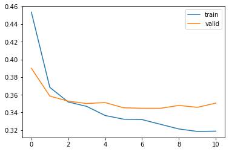

```python
# Capturing learning history per epoch
hist = pd.DataFrame(history_4.history)
hist["epoch"] = history_4.epoch

# Plotting accuracy at different epochs
plt.plot(hist["loss"])
plt.plot(hist["val_loss"])
plt.legend(("train", "valid"), loc=0)
```

- Here the model seems to be overfitted significantly, as the distance between the train curve and validation curve started increasing noticeably.

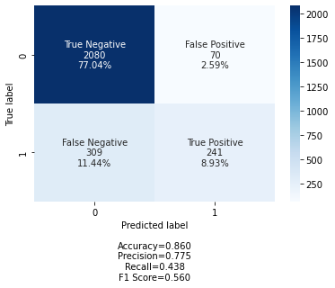

```python
## Confusion Matrix on unsee test set
import seaborn as sn

y_pred1 = model_4.predict(X_val)
for i in range(len(y_val)):
    if y_pred1[i] > 0.5:
        y_pred1[i] = 1
    else:
        y_pred1[i] = 0


cm4 = confusion_matrix(y_val, y_pred1)
labels = ["True Negative", "False Positive", "False Negative", "True Positive"]
categories = ["Not_Fraud", "Fraud"]
make_confusion_matrix(
    cm4,
    group_names=labels,
    # categories=categories,
    cmap="Blues",
)
```

##### Model-5

- I'm going to use a NN made of 4 fully-connected layers with ReLu activation. The NN takes a vector of length 10 as input. This represents the information related to each transactions, ie each line with 10 columns from the dataset. For each transaction, the final layer will output a probability distribution (sigmoid activation function) and classify either as not exited (0) or exited (1).
- I'm goint to try both BatchNormalization and dropout techniques and see if I can improve the metrics.
- And, I used Adam optimizer
- Also applied early stop technique too.

```python
backend.clear_session()
# Fixing the seed for random number generators so that we can ensure we receive the same output everytime
np.random.seed(42)
import random

random.seed(42)
tf.random.set_seed(42)
```

```python
# Initializing the model
model_5 = Sequential()
# Adding input layer with 64 neurons, relu as activation function and, he_uniform as weight initializer.
model_5.add(
    Dense(64, activation="relu", kernel_initializer="he_uniform", input_shape=(10,))
)
# Adding dropout with ratio of 0.1
model_5.add(Dropout(0.2))
# Adding the first hidden layer with 32 neurons, relu as activation function and, he_uniform as weight initializer
model_5.add(Dense(32, activation="relu", kernel_initializer="he_uniform"))
# Adding dropout with ratio of 0.1
model_5.add(Dropout(0.1))
# Adding the second hidden layer with 16 neurons, relu as activation function and, he_uniform as weight initializer
model_5.add(Dense(16, activation="relu", kernel_initializer="he_uniform"))
# Adding Batch Normalization
model_5.add(BatchNormalization())
# Adding the third hidden layer with 8 neurons, relu as activation function and, he_uniform as weight initializer
model_5.add(Dense(8, activation="relu", kernel_initializer="he_uniform"))
# We use the sigmoid because we want probability outcomes
model_5.add(Dense(1, activation="sigmoid"))  # binary classification fraudulent or not
```

```python
# Model summary
model_5.summary()
```

```
Model: "sequential"
_________________________________________________________________
 Layer (type)                Output Shape              Param #
=================================================================
 dense (Dense)               (None, 64)                704

 dropout (Dropout)           (None, 64)                0

 dense_1 (Dense)             (None, 32)                2080

 dropout_1 (Dropout)         (None, 32)                0

 dense_2 (Dense)             (None, 16)                528

 batch_normalization (BatchN  (None, 16)               64
 ormalization)

 dense_3 (Dense)             (None, 8)                 136

 dense_4 (Dense)             (None, 1)                 9

=================================================================
Total params: 3,521
Trainable params: 3,489
Non-trainable params: 32
_________________________________________________________________
```

```python
# Initializing the Optimizer
optimizer = Adam(0.001)
# Compiling the model with 'mse' as loss function and metrics
model_5.compile(optimizer=optimizer, loss="binary_crossentropy", metrics=["accuracy"])

# Defining Early stopping
es_cb = callbacks.EarlyStopping(monitor="val_loss", min_delta=0.001, patience=5)
# Fitting the model on train and validation with 50 epochs
history_5 = model_5.fit(
    X_train, y_train, validation_data=(X_val, y_val), epochs=50, callbacks=es_cb
)
```

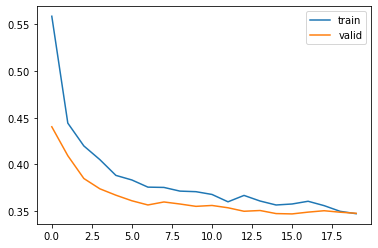

```python
# Capturing learning history per epoch
hist = pd.DataFrame(history_5.history)
hist["epoch"] = history_5.epoch

# Plotting accuracy at different epochs
plt.plot(hist["loss"])
plt.plot(hist["val_loss"])
plt.legend(("train", "valid"), loc=0)
```

- Here the model seems less overfitting.as the distance between the train curve and validation curve started narrowed down.

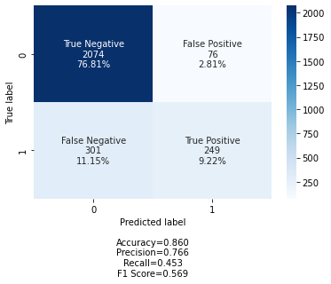

```python
## Confusion Matrix on unsee test set
import seaborn as sn

y_pred1 = model_5.predict(X_val)
for i in range(len(y_val)):
    if y_pred1[i] > 0.5:
        y_pred1[i] = 1
    else:
        y_pred1[i] = 0


cm2 = confusion_matrix(y_val, y_pred1)
labels = ["True Negative", "False Positive", "False Negative", "True Positive"]
categories = ["Not_Fraud", "Fraud"]
make_confusion_matrix(
    cm2,
    group_names=labels,
    # categories=categories,
    cmap="Blues",
)
```

#### Test Prediction

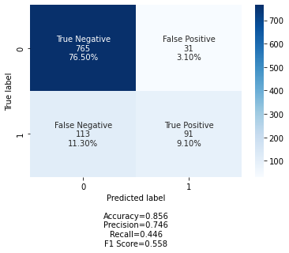

```python
## Confusion Matrix on unseen test set
import seaborn as sn

y_pred1 = model_2.predict(X_test)
for i in range(len(y_test)):
    if y_pred1[i] > 0.5:
        y_pred1[i] = 1
    else:
        y_pred1[i] = 0


cm2 = confusion_matrix(y_test, y_pred1)
labels = ["True Negative", "False Positive", "False Negative", "True Positive"]
categories = ["Not_Fraud", "Fraud"]
make_confusion_matrix(
    cm2,
    group_names=labels,
    # categories=categories,
    cmap="Blues",
)
```